# Practice 3: Basic Tabular Manipulation

This demonstration applies data transformations and tabular manipulation with `dplyr` to gain insight into patient health records.

#### Instructions

This demonstration provides a framework for inspecting data in the example healthcare data set. Skeleton code for the analysis is provided for you. Your job is to fill in missing code denoted by ellipses (`...`) in the notebook. Each ellipse includes a commented `TODO` statement above it with instructions. Please fill in the missing code in the notebook.

#### Scope

This notebook includes material covered in Lecture 3: Basic Tabular Manipulation. We will manipulate a data frame in the following ways…

1. Filter rows using single conditions and logical conjunctions
2. Compare values
3. Sort rows by multiple columns
4. Isolate a column
5. Rename a column
6. Create a new column from existing columns

#### Data Description

We will be working with synthetic patient records generated with the Synthea$^{\text{TM}}$ software package made available by The MITRE Corporation. The synthetic data models 1000 patient records and is stored in 16 CSV tables. The data source is cited below:

> Jason Walonoski, Mark Kramer, Joseph Nichols, Andre Quina, Chris Moesel, Dylan Hall, Carlton Duffett, Kudakwashe Dube, Thomas Gallagher, Scott McLachlan, Synthea: An approach, method, and software mechanism for generating synthetic patients and the synthetic electronic health care record, Journal of the American Medical Informatics Association, Volume 25, Issue 3, March 2018, Pages 230–238, https://doi.org/10.1093/jamia/ocx079

The data may be downloaded by clicking [this](https://synthetichealth.github.io/synthea-sample-data/downloads/synthea_sample_data_csv_apr2020.zip) hyperlink. **Please ensure that all tables are stored subdirectory called “data” placed immediately inside the directory containing this notebook.**

#### Import Modules

```r
library(ggplot2)
library(dplyr)
```

#### Specify and Load Data

In the subsequent code block, we use the `read.csv` function to load patient data stored in `data/patients.csv`. We will use the same approach that we used in the first two demonstrations.

```r
# TODO: Assign the value "data/patients.csv" to the variable `path`
path <- "data/patients.csv"

# TODO: Load the table using read.csv
df_patient <- read.csv(path, header = TRUE)
```

#### Identify Patient Ages at Some Reference Date

We will provide you with a reference date. Using the `BIRTHDATE` column in the `patients` table, you will identify the age of each patient at the reference date. Please use the `difftime` function to do this. This function returns the difference between two time points in specified units. The documentation for `difftime` can be found [here](https://www.rdocumentation.org/packages/base/versions/3.6.2/topics/difftime). We will store the patient ages in a new “age” column.

```r
# Age will be evaluated at January 1, 2023
ref_date <- as.Date("2023-01-01")

# Convert the `BIRTHDATE` column in the `patients` table to date format
df_patient$BIRTHDATE <- as.Date(df_patient$BIRTHDATE)

# TODO: Take the difference between the `BIRTHDATE` column in the `patients` table and the `ref_date`
# TODO: Represent the age in units of years (hint: if the age is given in days, divide by 365.25)
# TODO: Store the results in a new column called `age`
df_patient$age <- difftime(ref_date, df_patient$BIRTHDATE, units = "days") / 365.25

# For convenience, we express the age as a numerical value and round down to a whole number
df_patient$age <- as.numeric(df_patient$age)
df_patient$age <- floor(df_patient$age)

# Let's be more descriptive
# TODO: Rename the `age` column of the `patients` table to "age (years)"
# Hint: Use the `rename` function
df_patient <- rename(df_patient, "age (years)" = "age")
```

#### Sort Patients

Sort the patients by both their date of birth and their identifier. Report the patients in order of increasing age (most recent birthdays first), then alphabetical patient identifier. Please use the `arrange` function in the `dplyr` package to do this.

```r
# TODO: Sort patients by `BIRTHDATE` and `Id` using `dplyr`
df_patient <- df_patient %>%
  arrange(desc(BIRTHDATE), Id)

# Print the sorted `df_patient` table
print(df_patient)
```

```
##                                        Id  BIRTHDATE
## 1    d3f08bb8-e79f-4529-a37a-8aebdfbffe6a 2020-03-22
## 2    76811a9f-dd57-4949-9377-5c164d58665d 2020-03-04
## 3    b44d4f15-d604-4e24-8114-dc0dc12651d2 2020-02-13
## 4    dfc7b1ae-1583-4d88-970d-02712d55070c 2020-01-06
## 5    ef544417-a448-4c9d-8ddf-cb7fb513061d 2019-10-16
## 6    49cc8ae0-debc-428b-918c-75d3a635a19b 2019-08-16
## 7    c038adf1-91e4-4d05-a7ce-ba039b0259b4 2019-07-21
## 8    80bf0f47-724a-4254-b3ec-d54c15ad83b9 2019-07-05
## 9    a2aa6863-6e21-4b0a-b46c-40a6c0205a10 2019-06-13
## 10   293afb6b-b727-445a-a5b5-1c7a419ba7e2 2019-05-25
## 11   01207ecd-9dff-4754-8887-4652eda231e2 2019-05-15
## 12   194aca62-c623-4ba8-a7ca-bb77f17736f5 2019-03-30
## 13   98f91f0f-c03c-4da5-860a-c473d2c81983 2019-03-05
## 14   a698af9c-0f49-4aae-b965-55cc05fe2269 2018-12-21
```

[output cut: 10533 more lines]

#### Extract Patient Identifier and Age

If we are only interested in the patient ID and age, we may want to isolate those columns from the data frame. Please isolate the patient ID and age columns in their own data frame called `patient_ages`. Please use the `select` function in `dplyr` to do this. Also, isolate the age column into its own vector called `age_vector`.

```r
# TODO: Create a new data frame from the `Id` and `age (years)` columns of the `patients` table using `dplyr`
# Hint: Normally, with dplyr, we would not place quotes around column names.
# Hint: When a column name has a space in it, we can use `backticks` around the column name to select it
patient_ages <- df_patient %>%
  select(Id, `age (years)`)

# TODO: Isolate the age column into its own vector
# Hint: Use the `pull` function in `dplyr`
age_vector <- df_patient %>%
  pull(`age (years)`)
```

#### Plot the Distribution of Patient Ages

Plot a histogram of the patient ages. For more practice, add a vertical reference line at the mean age. Please use `ggplot` to do this.

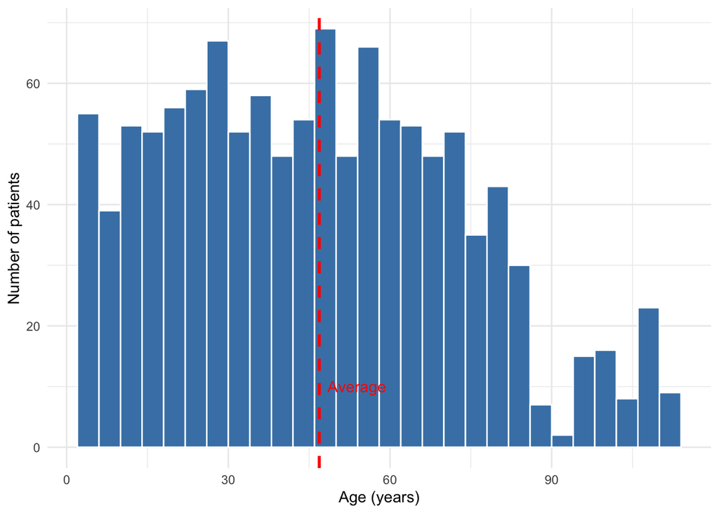

```r
# TODO: Plot a histogram of patient ages
ggplot(df_patient, aes(x = `age (years)`)) +
  geom_histogram(binwidth = 4, fill = "steelblue", color = "white") +
  labs(x = "Age (years)", y = "Number of patients") +
  geom_vline(xintercept = mean(age_vector), color = "red", linetype = "dashed", size = 1) +
  annotate("text", x = mean(age_vector) + 7, y = 10, label = "Average", color = "red") +
  theme_minimal()
```

#### Filter on a Single Condition

Filter the `patient_ages` data frame to patients under 18 years old, and store the filtered data frame in a variable called `under_18`. Then, filter the `patient_ages` data frame to patients over 65 years old, and store the filtered data frame in a variable called `over_65`. Please use `dplyr` to perform the filtering.

```r
# TODO: Isolate rows from `patient_ages` associated with patients under 18 years old
under_18 <- patient_ages %>%
  filter(`age (years)` < 18)

# TODO: Isolate rows from `patient_ages` associated with patients over 65 years old
over_65 <- patient_ages %>%
  filter(`age (years)` > 65)
```

#### Filter on Multiple Conditions

Filter the `patient_ages` data frame to patients who are under 18 years old **or** over 65 years old, and store the filtered data in a variable called `under_18_or_over_65`. Then, filter the `patient_ages` data frame to patients who are at least 18 years old **and** at most 65 years old, and store the filtered data in a variable called `between_18_and_65`. Use `dplyr` to perform both tasks.

```r
# TODO: Isolate rows from `patient_ages` associated with patients under 18 years old or over 65 years old
under_18_or_over_65 <- patient_ages %>%
  filter(`age (years)` < 18 | `age (years)` > 65)

# TODO: Isolate rows from `patient_ages` associated with patients >=18 years old and <=65 years old
between_18_and_65 <- patient_ages %>%
  filter(`age (years)` >= 18) %>%
  filter(`age (years)` <= 65)

# CHECKING WORK: The code below checks that no patients were lost during the filtering process
# If this code block runs successfully without an error, your work is correct!
stopifnot(nrow(under_18_or_over_65) + nrow(between_18_and_65) == nrow(patient_ages))
```

#### Create New Columns using Existing Columns

Using the `mutate` function in `dplyr` and the `sapply` in base R, create a new column in the `patient_ages` table called `"age_group"` with the following values: `"minor"` if the patient is under 18 years old, `"adult"` if the patient is between 18 and 65 years old, and `"older adult"` if the patient is over 65 years old. To support this task, we provide the function `get_age_group` that takes a numerical age in years and returns the associated age group.

```r
# We will provide a function for identifying age category
# The function accepts a numerical age and returns a string age category
get_age_group <- function(age) {
  if (age < 18) {
    return("minor")
  } else if (age >= 18 && age <= 65) {
    return("adult")
  } else {
    return("older adult")
  }
}

# TODO: Apply the function to the `age` column of `patient_ages` to obtain the age category of each patient
# Hint: Use the `mutate` function in dplyr to define the `age_group` column
# Hint: Use the `sapply` function to apply the `get_age_group` function to the `age (years)` column
patient_ages <- patient_ages %>%
  mutate(age_group = sapply(`age (years)`, get_age_group))
```

#### Grouped Summaries

Calculate the average age of patients in the three age groups: `"minor"`, `"adult"`, and `"older adult"`. Use the `group_by` and `summarize` functions in `dplyr` to complete this task.

```r
# TODO: Calculate the average age in each age group
age_group_averages <- patient_ages %>%
  group_by(age_group) %>%
  summarize(
    mean_age = mean(`age (years)`),
  )

# Print the age group averages
print(age_group_averages)
```

```
## # A tibble: 3 x 2
##   age_group   mean_age
## * <chr>          <dbl>
## 1 adult          41.3
## 2 minor           9.93
## 3 older adult    82.3
```

#### Summary

In this notebook, we investigated the age distribution of patients in our records. We started by calculating age using each patient’s date of birth. We visualized the distribution of ages using a histogram. We then filtered patients according to age criteria, and we assigned patients into age categories. Finally, we calculated the average age for each age category.